# sample-matching_IPUMS-NQ_CL

Maita Schade

May 9, 2019

run: *Ctrl+Shift+Enter*. New chunk: *Ctrl+Alt+I*. *Ctrl+Shift+K* to preview the HTML file.

Make sure we’re dealing with a clear space:

```r
country = "CL"
strat1 = "GEO1_CL2002"
strat2 = "URBAN"
NQ_id  = "gp_codigo"
setwd(
  paste0("C:/Users/schadem/Box Sync/LAPOP Shared/working documents/maita/Coordination/IDB Online/Matching process/Data/",country)
)
```

```
The working directory was changed to C:/Users/schadem/Box Sync/LAPOP Shared/working documents/maita/Coordination/IDB Online/Matching process/Data/CL inside a notebook chunk. The working directory will be reset when the chunk is finished running. Use the knitr root.dir option in the setup chunk to ch…
```

```r
library('MatchIt')
library('haven')
library('openxlsx')
library('labelled')
library(zoo)
library('plyr')
require('cem')
require('sampleMatch')
```

Reading in the sampling data and making necessary updates.

Here, we are using the IPUMS data.

```r
census<- read.csv(
  paste0('C:/Users/schadem/Box Sync/LAPOP Shared/working documents/maita/Coordination/IDB Online/Matching process/Data/',country,'/sample/',country,'_ipums-census_geo.csv')
  )
```

```r
netquest <- read.csv(
  paste0("C:/Users/schadem/Box Sync/LAPOP Shared/working documents/maita/Coordination/IDB Online/Matching process/Data/",
  country,
  "/panel/", country, "_netquest-panel_geo.csv")
)
#netquest<-netquest[!duplicated(netquest$gp_codigo),]
```

(Save this workspace to facilitate processing later on.)

```r
save.image(paste0(country,"_data_loaded.RData"))
```

We have to recode the various characteristics we have at our disposal.

```r
matching.vars <- c('gend',
                   'age',
                   'ed',
                   'ed_hhh',
                   'emp',
                   'emp_hhh',
                   #'san',
                   'auto',
                   'cell',
                   #'insur_hhh',
                   #'walls',
                   #'floors',
                   'child',
                   'marst',
                   'pern',
                   'hhtype',
                   'hhh',
                   #'prov', using X and Y instead of province
                   'X',
                   'Y'
                   )
```

Gender: is fine.

```r
census$gend <- census$SEX
netquest$gend <- netquest$p_sexo
table(netquest$gend)
```

```
     1      2
173127 232151
```

Age: is fine, need to filter these to make sure we exclude too young respondents.

Education: EDUCCL partially matches CL_education_level; the census doesn’t count postgrad so have to collapse in panel

```r
#census$ed <- vector(length=length(census$EDUCCL))
census$ed[census$EDUCCL==0] <- 1
census$ed[census$EDUCCL>=221 & census$EDUCCL<=227] <- 2
census$ed[census$EDUCCL==228] <- 3
census$ed[census$EDUCCL>=311 & census$EDUCCL<=393] <- 4
census$ed[census$EDUCCL %in% c(316, 324,325, 334,335, 344, 345, 354, 355, 364, 365, 386, 387, 394)] <- 5
census$ed[census$EDUCCL>=400] <- 6
netquest$ed <- mapvalues(as.integer(netquest$CL_education_level),
        from=c(6, 7, 8, 9),
        to=  c(6, 6, 6, 6))
table(census$ed)
```

```
     1      2      3      4      5      6
 36736 429159 116647 257991 265562 350550
```

```
Need head of household, as well.
```

Employment. Reconsider ordering.

```r
table(census$emp)
```

```
     1      2      3      4      5      6      8      9
112351 454419 259601 129635  11379  10900 134985  10819
```

Employment of head of household: There’s a question of how to map “living on rents” (341), 390 “inactive”

```r
census$emp_hhh <- mapvalues(census$EMPSTATD_HEAD,
        from=c(110,120,330,210,220,390,340,320,310,  0),
        to=  c(  1,  1,  4,  6,  5,  8,  8,  9,  3, NA))
census$emp_hhh[census$CLASSWK_HEAD==2]<- 2
netquest$emp_hhh <- mapvalues(netquest$CL_laboral_situation_hhousehold,
       from=c(1,2,3,4,5,6,7,8,9),
       to=  c(1,2,4,6,5,8,8,9,3))
table(census$emp_hhh)
```

```
     1      2      3      4      5      6      8      9
242360 758041 200465  11006   4079  21851 231366  13222
```

Auto

```r
census$auto <- mapvalues(census$AUTOS,
        from=c(0,7,9),
        to=  c(2,1,NA))
netquest$auto <- mapvalues(netquest$CL_NSE_hasvehicle_hhousehold,
       from=c(1,2),
       to=  c(1,2))
table(census$auto)
```

```
      1       2
 345676 1136782
```

Cellphone (this may be a bad variable in Chile given the changes since 2002)

```r
table(census$cell)
```

```
     1      2
798391 684067
```

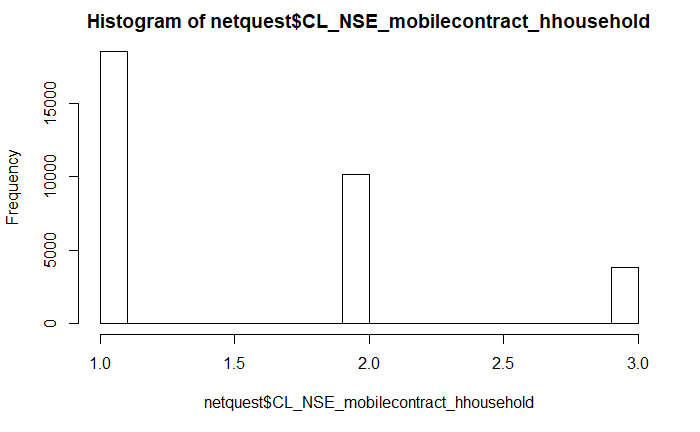

Children

```r
table(census$child)
```

```
     0      1      2      3      4      5      6      7
927374 244728 209199  95172  28466   6324   1825    826
```

Marital status: need P1 from Netquest!

```r
table(netquest$marst)
```

```
     1      2      3      4
223223  26705   2555 152793
```

[output not shown]

number of persons in household

```r
table(census$pern)
```

```
     1      2      3      4      5      6      7      8      9     10     11     12     13     14     15     16     17     18     19     20     21     22     23     24     25     26     27     28     29     30
 69386 145864 270105 383392 291245 174990  80941  42232  22077  12310   7326   4404   2353   1638   1065    832    493    288    247    460    336    264    138    192    200    156    216    140    174    450
```

type of household

```r
table(netquest$hhtype)
```

```
     0      1      2      3      4      5      6
 55520  17880  36037  20291  95116 161547  18881
```

head of household?

```r
table(netquest$hhh)
```

```
     1      2
236842 168428
```

Give ID to both datasets, so we can go back to IDs when necessary

```r
census$id <- seq(dim(census)[1])
netquest$id <- seq(dim(netquest)[1])
```

Create the sample and panel from this:

If we do some non-numeric matching, we’d want to adjust the labels/levels.

```
      gend            age               ed            ed_hhh           emp           emp_hhh          auto            cell           child            marst            pern            hhtype          hhh
 Min.   :1.000   Min.   : 18.00   Min.   :1.000   Min.   :1.000   Min.   :1.000   Min.   :1.00   Min.   :1.000   Min.   :1.000   Min.   :0.0000   Min.   :1.000   Min.   : 1.000   Min.   :0.00   Min.   :1.000
 1st Qu.:1.000   1st Qu.: 21.00   1st Qu.:5.000   1st Qu.:5.000   1st Qu.:2.000   1st Qu.:2.00   1st Qu.:1.000   1st Qu.:1.000   1st Qu.:0.0000   1st Qu.:1.000   1st Qu.: 3.000   1st Qu.:2.00   1st Qu.:1.000
 Median :2.000   Median : 27.00   Median :6.000   Median :6.000   Median :2.000   Median :2.00   Median :2.000   Median :1.000   Median :0.0000   Median :1.000   Median : 4.000   Median :5.00   Median :1.000
 Mean   :1.502   Mean   : 30.77   Mean   :5.152   Mean   :5.006   Mean   :3.114   Mean   :2.54   Mean   :1.599   Mean   :1.114   Mean   :0.7726   Mean   :1.966   Mean   : 4.241   Mean   :3.52   Mean   :1.476
 3rd Qu.:2.000   3rd Qu.: 37.00   3rd Qu.:6.000   3rd Qu.:6.000   3rd Qu.:4.000   3rd Qu.:2.00   3rd Qu.:2.000   3rd Qu.:1.000   3rd Qu.:1.0000   3rd Qu.:4.000   3rd Qu.: 5.000   3rd Qu.:5.00   3rd Qu.:2.000
 Max.   :2.000   Max.   :108.00   Max.   :6.000   Max.   :6.000   Max.   :9.000   Max.   :9.00   Max.   :2.000   Max.   :2.000   Max.   :7.0000   Max.   :4.000   Max.   :15.000   Max.   :6.00   Max.   :2.000
       X                Y                id
 Min.   :-83.36   Min.   :-53.68   Min.   :   124
 1st Qu.:-71.52   1st Qu.:-34.07   1st Qu.:138831
 Median :-70.80   Median :-33.51   Median :276832
 Mean   :-71.32   Mean   :-33.55   Mean   :277981
 3rd Qu.:-70.60   3rd Qu.:-33.35   3rd Qu.:416990
 Max.   :-68.20   Max.   :-18.50   Max.   :554819
```

ADJUST FOR COUNTRY!

```
      gend            age               ed            ed_hhh           emp           emp_hhh           auto            cell           child           marst            pern            hhtype           hhh
 Min.   :1.000   Min.   : 18.00   Min.   :0.000   Min.   :0.000   Min.   :1.000   Min.   :1.000   Min.   :1.000   Min.   :1.000   Min.   :0.000   Min.   :1.000   Min.   : 1.000   Min.   :0.000   Min.   :1.000
 1st Qu.:1.000   1st Qu.: 29.00   1st Qu.:2.000   1st Qu.:2.000   1st Qu.:2.000   1st Qu.:2.000   1st Qu.:2.000   1st Qu.:1.000   1st Qu.:0.000   1st Qu.:1.000   1st Qu.: 3.000   1st Qu.:4.000   1st Qu.:1.000
 Median :2.000   Median : 39.00   Median :4.000   Median :4.000   Median :2.000   Median :2.000   Median :2.000   Median :1.000   Median :1.000   Median :4.000   Median : 4.000   Median :4.000   Median :2.000
 Mean   :1.522   Mean   : 41.92   Mean   :4.018   Mean   :3.811   Mean   :3.141   Mean   :3.231   Mean   :1.762   Mean   :1.466   Mean   :1.085   Mean   :2.953   Mean   : 4.212   Mean   :4.167   Mean   :1.595
 3rd Qu.:2.000   3rd Qu.: 53.00   3rd Qu.:5.000   3rd Qu.:5.000   3rd Qu.:3.000   3rd Qu.:3.000   3rd Qu.:2.000   3rd Qu.:2.000   3rd Qu.:2.000   3rd Qu.:4.000   3rd Qu.: 5.000   3rd Qu.:5.000   3rd Qu.:2.000
 Max.   :2.000   Max.   :100.00   Max.   :6.000   Max.   :6.000   Max.   :9.000   Max.   :9.000   Max.   :2.000   Max.   :2.000   Max.   :7.000   Max.   :4.000   Max.   :30.000   Max.   :6.000   Max.   :2.000
       X                Y              URBAN           PERWT     GEO1_CL2002           id
 Min.   :-83.36   Min.   :-53.68   Min.   :1.000   Min.   :10   Min.   : 11.00   Min.   :      1
 1st Qu.:-72.13   1st Qu.:-36.62   1st Qu.:2.000   1st Qu.:10   1st Qu.: 61.00   1st Qu.: 384609
 Median :-70.82   Median :-33.53   Median :2.000   Median :10   Median : 92.00   Median : 766879
 Mean   :-71.50   Mean   :-34.19   Mean   :1.868   Mean   :10   Mean   : 94.08   Mean   : 762522
 3rd Qu.:-70.63   3rd Qu.:-33.40   3rd Qu.:2.000   3rd Qu.:10   3rd Qu.:131.00   3rd Qu.:1140064
 Max.   :-68.20   Max.   :-18.50   Max.   :2.000   Max.   :10   Max.   :136.00   Max.   :1513914
```

sample! Stratified by urban/rural and by region, weighted !REMEMBER TO MATCH THE SEED!

```r
n <- 1200
set.seed(111)
strats=c(strat1,strat2)
library(sampleMatch)
target  <- strat_weight_sample(census.proc,strats,'PERWT',n)
```

```
PERWT ~ GEO1_CL2002 + URBAN
<environment: 0x00000248e8afc8a0>
```

```r
#add Fakeid, so we can keep those from the panel in the matching set
target['Fakeid'] <- as.integer(rep(999999, length(target$age)))
```

Making sure this stratification worked…

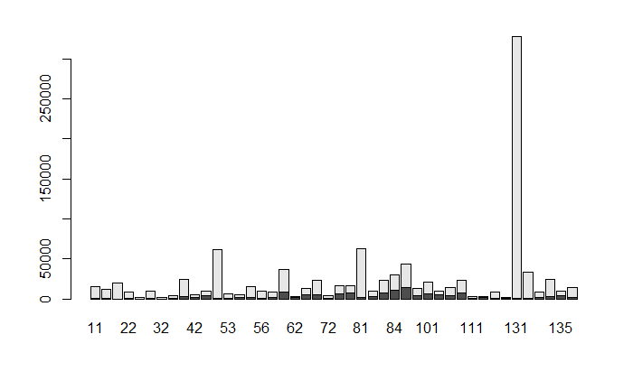

Add a treatment into it:

```r
panel['treat'] <- rep(0,length(panel$age))
target['treat'] <- rep(1,length(target$age))
```

Now join this data together:

```r
levels(panel$Fakeid) <- c(levels(panel$Fakeid),999999) #to make room for the non-existent Fakeid
alldata<-rbind(panel,target[names(panel)])
#jointId will be the sequence number in the joint dataframe -- MAY NOT NEED THIS?
alldata$jointId <- seq(dim(alldata)[1])
rownames(alldata) <- alldata$jointId
unique(table(alldata$id)) #a person can be repeated in the target!!
```

```
[1] 1 2
```

Divide target sample into age quantiles (in this case, deciles) and add that to the data:

# for the methods that require numeric approximation

```r
alldata_num<-data.frame(lapply(alldata, as.numeric))
```

```
      gend            age               ed            ed_hhh          emp           emp_hhh          auto            cell           child            marst            pern           hhtype          hhh
 Min.   :1.000   Min.   : 18.00   Min.   :0.000   Min.   :0.00   Min.   :1.000   Min.   :1.00   Min.   :1.000   Min.   :1.000   Min.   :0.0000   Min.   :1.000   Min.   : 1.00   Min.   :0.00   Min.   :1.000
 1st Qu.:1.000   1st Qu.: 22.00   1st Qu.:5.000   1st Qu.:4.00   1st Qu.:2.000   1st Qu.:2.00   1st Qu.:1.000   1st Qu.:1.000   1st Qu.:0.0000   1st Qu.:1.000   1st Qu.: 3.00   1st Qu.:2.00   1st Qu.:1.000
 Median :2.000   Median : 27.00   Median :6.000   Median :6.00   Median :2.000   Median :2.00   Median :2.000   Median :1.000   Median :0.0000   Median :1.000   Median : 4.00   Median :5.00   Median :1.000
 Mean   :1.502   Mean   : 31.09   Mean   :5.118   Mean   :4.97   Mean   :3.117   Mean   :2.56   Mean   :1.604   Mean   :1.125   Mean   :0.7819   Mean   :1.996   Mean   : 4.24   Mean   :3.54   Mean   :1.481
 3rd Qu.:2.000   3rd Qu.: 38.00   3rd Qu.:6.000   3rd Qu.:6.00   3rd Qu.:4.000   3rd Qu.:2.00   3rd Qu.:2.000   3rd Qu.:1.000   3rd Qu.:1.0000   3rd Qu.:4.000   3rd Qu.: 5.00   3rd Qu.:5.00   3rd Qu.:2.000
 Max.   :2.000   Max.   :108.00   Max.   :6.000   Max.   :6.00   Max.   :9.000   Max.   :9.00   Max.   :2.000   Max.   :2.000   Max.   :7.0000   Max.   :4.000   Max.   :17.00   Max.   :6.00   Max.   :2.000
       X                Y                id              treat            jointId        age_group
 Min.   :-83.36   Min.   :-53.68   Min.   :    124   Min.   :0.00000   Min.   :    1   Min.   : 1.000
 1st Qu.:-71.52   1st Qu.:-34.13   1st Qu.: 141391   1st Qu.:0.00000   1st Qu.: 8070   1st Qu.: 2.000
 Median :-70.81   Median :-33.51   Median : 283123   Median :0.00000   Median :16138   Median : 3.000
 Mean   :-71.32   Mean   :-33.57   Mean   : 292968   Mean   :0.03089   Mean   :16138   Mean   : 3.643
 3rd Qu.:-70.60   3rd Qu.:-33.36   3rd Qu.: 426216   3rd Qu.:0.00000   3rd Qu.:24207   3rd Qu.: 5.000
 Max.   :-68.20   Max.   :-18.50   Max.   :1513740   Max.   :1.00000   Max.   :32276   Max.   :10.000
```

Now the matching begins. This is using the MatchIt package as we are used to…

```r
matching.form <- as.formula(paste0("treat ~ ", paste(matching.vars, collapse=' + ')))
```

We’ll have to repeat this process (at least for everything except PS), since the memory can’t deal with all of this. * start empty dataframe initialized with target IDs * make a copy of the data to alter * for each i in range: + run the matching + store the matched IDs + store some overall metrics about the match + reduce the panel data * return the match objects

```r
matchRatio <- function(data, metric, n, exact = c()){

  # assign the dataframe to hold the matching results
  df <- data.frame(matrix(ncol=1, nrow=sum(data$treat==1)))
  names(df) <- c("targetId")
  df$targetId <- data$id[data$treat==1]

  # assign the object to hold all the matching information
  matches <- vector("list",n)

  # make a copy of the passed-in data
  data.copy <- data.frame(data)

  # loop over the number of respondents per target
  # if there are issues, can I relax the age groups?
  for(i in 1:n){
    print(paste('i = ',to_character(i)))
    m <- matchit(matching.form,
                 data = data.copy, exact=exact, method = "nearest", distance = metric)

    try({matches[[i]] <- m
        targetids <- data.copy[row.names(m$match.matrix), "id"]
        panelids <- as.data.frame(data.copy[m$match.matrix,"Fakeid"])
        names(panelids)<-c("panelId")
        panelids['targetId']<-targetids
        df <- merge(x=df, y=panelids, by="targetId", all.x = TRUE, suffixes=c("",to_character(i)))
        } #... maybe merge instead might be safer?
    )

    controls <- match.data(m, group='control')
    data.copy <- data.copy[!data.copy$jointId %in% controls$jointId,] # not relying on rownames

  }
  return(list("ids"=df, "matches"=matches))
}
```

```r
matches.cem_mah = matchRatio(alldata_num, "mahalanobis", 1, exact = c("age_group","gend"))
```

```
[1] "i =  1"
```

Save the id’s of the matches to a file, so I don’t lose them–just in case

```r
tmp <- matches.cem_mah$ids
# attaching NQ panel code
tmp[NQ_id] <- merge(x = matches.cem_mah$ids,
                    y = alldata[alldata$treat==0, c("Fakeid",'id')],
                    by.x = "panelId",
                    by.y = "id")[["Fakeid"]]
# attaching census identification, just in case!
tmp[c("SERIAL","PERNUM")] <- merge(x = matches.cem_mah$ids,
                                   y = census[c("SERIAL","PERNUM","id")],
                                   by.x = 'targetId',
                                   by.y = 'id')[c("SERIAL","PERNUM")]
write.csv(x=tmp[c("targetId",NQ_id, "SERIAL","PERNUM")], file=paste0("C:/Users/schadem/Box Sync/LAPOP Shared/working documents/maita/Coordination/IDB Online/Matching process/Data/",country,"/panel/matches_cem-mah.csv"))
```

```r
dim(tmp)
```

```
[1] 1205    5
```